# Part II - (Student Performance in Exams)

## by (Jennifer Ashishali Ochonogor)

## Investigation Overview

In this part of the project, a slide deck will be used for explanatory data visualizations that tells a story about the data exploration in Part I. The questions raised in the exploration phase have been answered as stated below, and polished plots will be rendered so that they can be presented in an understandable form.

**Key Insights on Questions**

- In comparing the test preparations across the parent's education level, and ethnic group A, which is associated with a high rate of completing preparation courses, we have been able to measure how effective test preparation courses are by the notable difference in test scores seen across each group.
- We have also uncovered some determining factors of test outcomes. We know that subject plays a role by the distribution of scores in math to reading and writing based on the gender of the student. Socio-Economic factors like Lunch plan, which measures the household income of each student, Parent Level of Education which accounts for family environment and support, and Ethnicity which measures school support in minority represented groups are key factors in test scores.

## Dataset Overview

The data explored is a fictional dataset sourced from [Kaggle](https://www.kaggle.com/datasets/whenamancodes/students-performance-in-exams?resource=download) which consists of the marks secured by students in various subjects.The dataset contains 24000 values representing 8 variables and 3000 observations. The variables are:

> - id, unique identifier for each student
> - gender, with two possible values (male and female).
> - ethnicity, with five possible values (group A, group B, group C, group D, and group E).
> - parent_education, with six possible values (some high school, high school, some college, associate's degree, bachelor's degree, and master's degree).
> - lunch, with two possible values (standard and free/reduced)
> - test_prep, with two possible values (completed and none)
> - subject, with three possible values (math, writing, and reading)
> - score, with a range of values for each subject

Main feature of interest is the test outcome of each subject, *score*. Other supporting features are test preparations, gender and socio-economic factors like eligible lunch program, parental level of education, and ethnicity.

## How effective is the test preparation course?

### Test Preparation by Ethnicity

We compared test preparations to test scores, and gleaned the group most associated with completed test preparations. We found that students from the least represented ethnic group, group A had an engagement of approximately 41% , which is comparatively higher compared to the other ethnic groups.

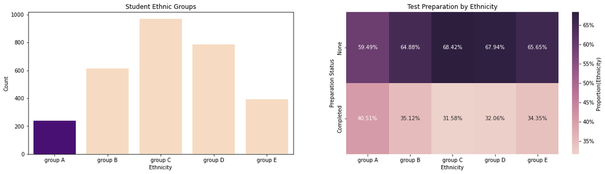

### Distribution of Test Scores on Ethnicity by Test Preparations

An interaction of each ethnic group with test preparations and its effect on test scores was further investigated. We can see the median scores for completed test preparations are higher with each ethnic group compared to no test preparations. Also, the height of the IQR for group A, the group with the highest rate of completed test preparation is comparatively shorter in completed preparations than in no preparations. This suggests that students in group A for completed test preparation courses have a higher level of agreement in scores compared to the group A in no test preparations.

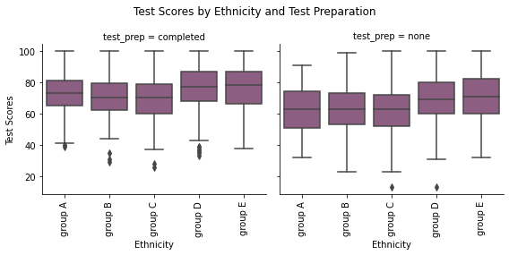

### Socio-Economic Measures on Test Scores by Status of Preparation

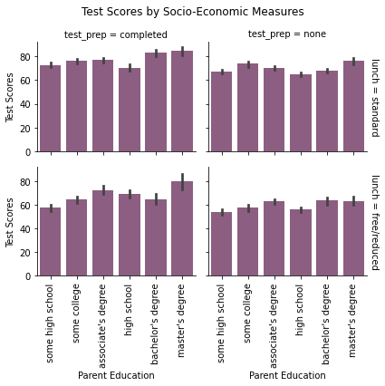

## Which major factors contribute to test outcomes?

### Test Scores by Gender

We know that subject plays a role by the distribution of scores in math to reading and writing based on the gender of the student. The box plot below shows the variation of test scores for both genders based on the median, we can observe that female students excel more in Reading and Writing, while male students excel more at Math.

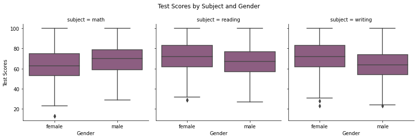

### Socio-Economic Measures on Test Scores

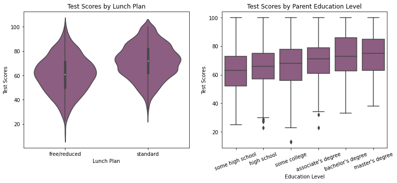

## To answer the last question: What would be the best way to improve student scores on each test?

Based on the data, to improve the test scores for students, I will suggest an increase in the engagement of test preparation courses, particularly on the subject each gender is shown to be weaker at, and an introduction of school related motivational and engagement activities targeted at students with low parental education background.